# COVID-19 Forecast Hub report, 2020-07-27

Nicholas G Reich, Estee Y Cramer

2020-07-29

# Background

This report provides a brief summary of the weekly ensemble forecast from the [COVID-19 Forecast Hub](https://covid19forecasthub.org/). In collaboration with the US CDC, our team aggregates COVID-19 forecasts from dozens of teams around the globe. Typically on Wednesday or Thursday of each week, a summary of the week’s forecasts from the COVID-19 Forecast Hub appear on the [official CDC COVID-19 forecasting page](https://www.cdc.gov/coronavirus/2019-ncov/covid-data/forecasting-us.html).

Every week, teams submit their forecasts to the COVID-19 Forecast Hub. This past week, 40 models were submitted, including two models from new teams.

Each Tuesday, we combine the most recent forecasts from each team into a single “ensemble” forecast of reported COVID-19 cases at the county, state, and national level and deaths at the state and national level. At the moment, we only generate ensemble forecasts for four weeks into the future, as we don’t have reliable evidence that the models are accurate past that horizon.

This week, we are trying something a bit different, and providing a web-based report that summarizes some of the key findings from our modeling this week. We expect that these reports will become more detailed as the weeks go on.

# Weekly Summary

This week, our ensemble combined forecasts from 31 different models. At the national level, the ensemble model’s best guess is that we will see between 6,900 and 7,500 deaths each week for the next four weeks with around 173,300 deaths by August 22nd (Figure 1). However for the week ending August 22nd, the ensemble shows substantial uncertainty, with observed deaths between 5,000 and 10,000 deemed possible (95% prediction interval: 4,661 - 11,198).

In the past 4-5 weeks, models have in general shown broad agreement about the trajectory of the outbreak over the coming weeks. However, the recent surge in cases has left models with quite different interpretations about what the next few weeks hold in terms of how many reported deaths from COVID-19 we will see. You can explore the full set of models, including their forecasts for past weeks online at our [interactive forecast visualization](https://viz.covid19forecasthub.org/).

Figure 1: Weekly observed and forecasted COVID-19 deaths. Observed data from [JHU CSSE](https://github.com/CSSEGISandData/COVID-19/tree/master/csse_covid_19_data/) and forecasts from the [COVID-19 Forecast Hub](https://covid19forecasthub.org/).

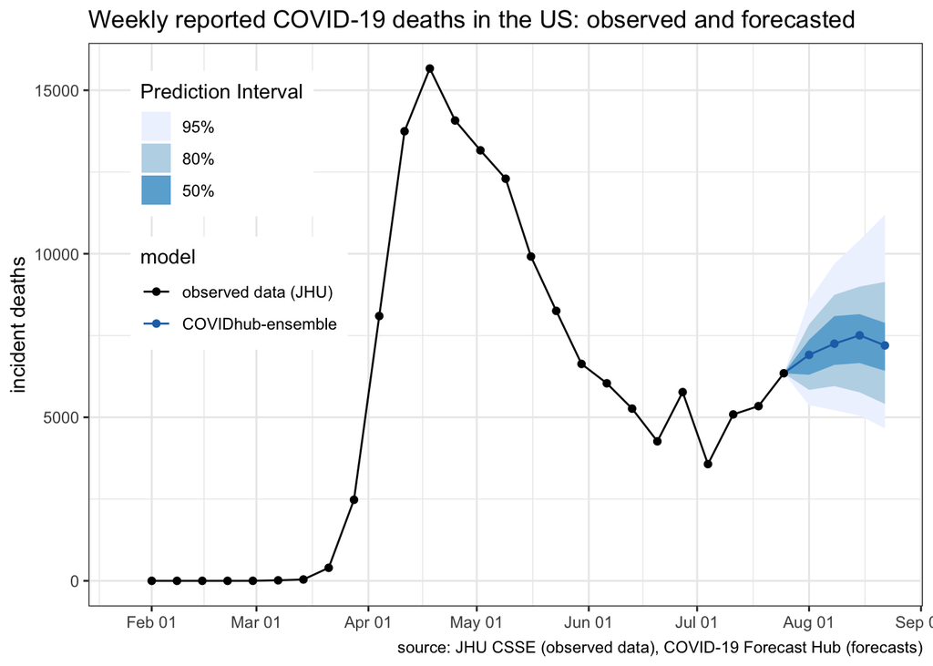

The sortable and searchable table below shows the total number of reported COVID-19 deaths at the US level and by state over the last two weeks (ending Saturday, July 25, 2020) and the forecasted counts for the subsequent two weeks (ending August 8, 2020).

| state | Population | Total COVID-19 deaths | COVID-19 deaths, last 2 weeks | COVID-19 deaths, next 2 weeks | Difference |
| --- | --- | --- | --- | --- | --- |
| Alabama | 4903185 | 1456 | 342 | 408 | 66 |
| Alaska | 731545 | 20 | 3 | 7 | 4 |
| Arizona | 7278717 | 3286 | 1135 | 955 | -180 |
| Arkansas | 3017804 | 399 | 80 | 91 | 11 |
| California | 39512223 | 8408 | 1381 | 1570 | 189 |
| Colorado | 5758736 | 1794 | 69 | 93 | 24 |
| Connecticut | 3565287 | 4413 | 65 | 34 | -31 |
| Delaware | 973764 | 579 | 62 | 24 | -38 |
| District of Columbia | 705749 | 581 | 13 | 11 | -2 |
| Florida | 21477737 | 5777 | 1580 | 1928 | 348 |

[output cut: 46 more lines]

The sortable and searchable table below shows the total number of reported COVID-19 deaths at the US level and by state as of Saturday, July 25, 2020 (“Total COVID-19 Deaths”) as well as the rate of reported COVID-19 deaths in the population (standardized per 100,000 population) over the last two weeks and over the next two weeks. Looking at the rates allows for easier comparison across states, where you can see which states have had or are predicted to have propoportionally higher rates in comparison to other states. These tables calculate an average daily number of deaths per 100,000 population across the last two weeks (ending Saturday, July 25, 2020) and forecasted for the following two weeks (ending August 8, 2020).

| state | Population | Total COVID-19 deaths | Daily deaths per 100k, last 2 weeks | Daily deaths per 100k, next 2 weeks | Death rate difference |
| --- | --- | --- | --- | --- | --- |
| Alabama | 4903185 | 1456 | 0.498 | 0.594 | 0.096 |
| Alaska | 731545 | 20 | 0.029 | 0.068 | 0.039 |
| Arizona | 7278717 | 3286 | 1.114 | 0.937 | -0.177 |
| Arkansas | 3017804 | 399 | 0.189 | 0.215 | 0.026 |
| California | 39512223 | 8408 | 0.25 | 0.284 | 0.034 |
| Colorado | 5758736 | 1794 | 0.086 | 0.115 | 0.029 |
| Connecticut | 3565287 | 4413 | 0.13 | 0.068 | -0.062 |
| Delaware | 973764 | 579 | 0.455 | 0.176 | -0.279 |
| District of Columbia | 705749 | 581 | 0.132 | 0.111 | -0.021 |
| Florida | 21477737 | 5777 | 0.525 | 0.641 | 0.116 |

[output cut: 46 more lines]